Lake Name: Cossayuna Lake

Lake acreage: 649.2

County: WASHINGTON

PWLID: 1103-0002

Waterbody Classification: A

Coordinates: 43.2006,-73.423401

Is this waterbody a public water supply: No

Are there DOH desingated beaches on this waterbody: No

Open Water Indicators

2018 Sampling Results

Seasonal Change

05-29

06-11

06-26

07-10

07-30

08-13

08-27

09-10

Clarity (m)

7.50

7.00

4.95

4.00

3.00

3.45

2.20

1.95

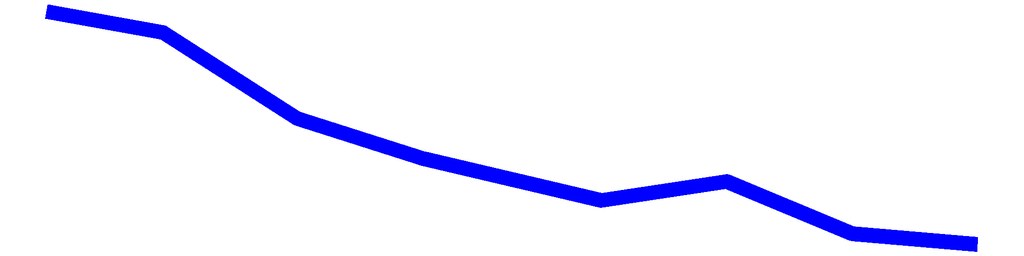

Surface TP (mg/L)

0.02

0.01

0.02

0.02

0.02

0.02

0.03

0.03

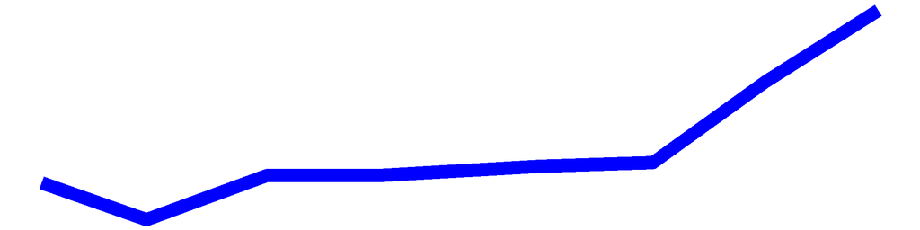

Surface TDP (mg/L)

0.01

0.00

0.01

0.01

0.01

0.01

0.01

0.01

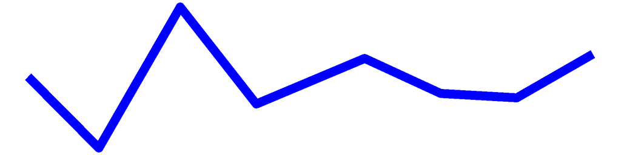

Deep TP (mg/L)

0.01

0.01

0.02

0.02

0.05

0.06

0.03

0.03

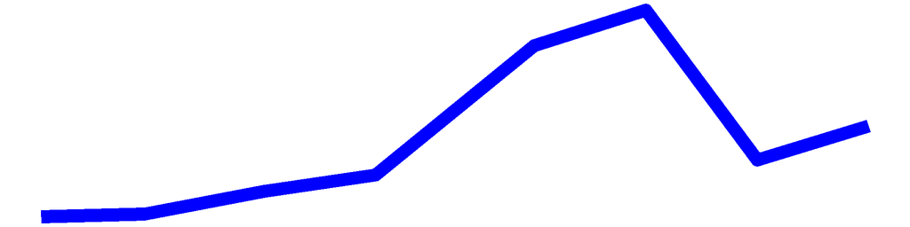

Deep TDP (mg/L)

0.00

0.01

0.01

0.01

0.03

0.04

0.02

0.01

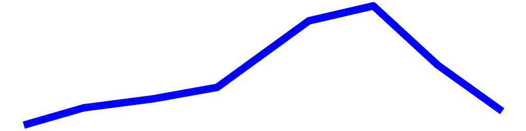

TN (mg/L)

0.52

0.40

0.53

0.50

0.51

0.52

0.71

1.13

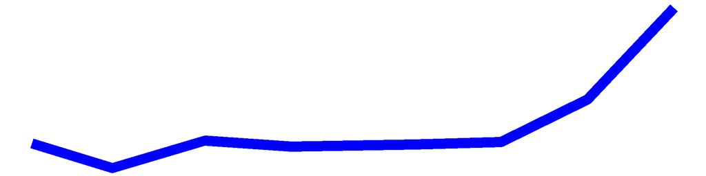

TDN (mg/L)

0.42

0.36

0.52

0.50

0.26

0.34

0.63

1.18

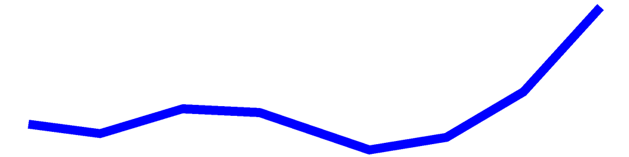

TN:TP

33.25

33.81

32.59

30.84

29.84

29.77

28.15

34.98

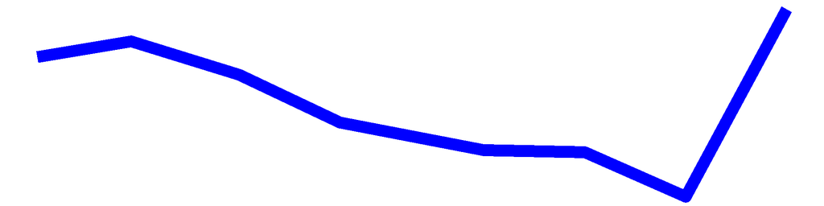

Surface NH3 (mg/L)

0.03

0.02

0.03

0.04

0.05

0.02

0.11

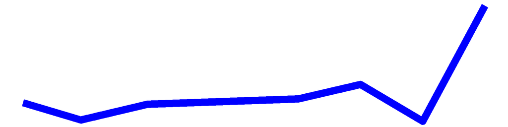

Deep NH3 (mg/L)

0.05

0.08

0.07

0.02

0.22

0.22

0.20

0.14

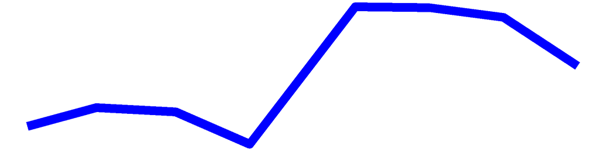

Chl.a (ug/L)

1.10

1.20

1.30

5.10

3.60

12.40

6.20

7.70

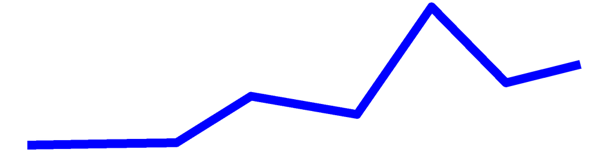

pH

7.92

7.42

8.00

7.83

7.43

7.68

8.12

7.71

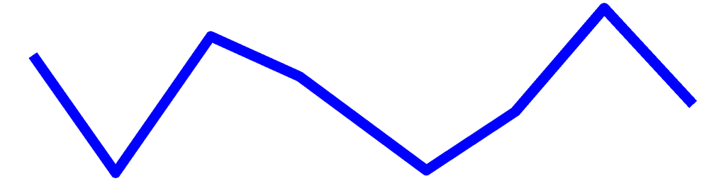

Cond (umho/cm)

166.00

202.20

224.10

212.80

214.10

208.80

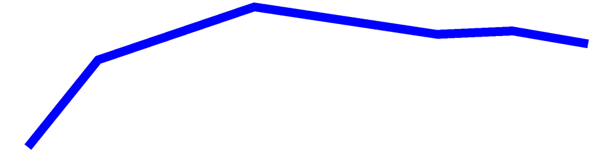

Surface Calcium (mg/L)

Bottom Calcium (mg/L)

Surface Chloride (mg/L)

22.50

19.60

Bottom Chloride (mg/L)

Upper Temp (degC)

20.00

24.00

21.00

27.00

25.00

27.00

24.00

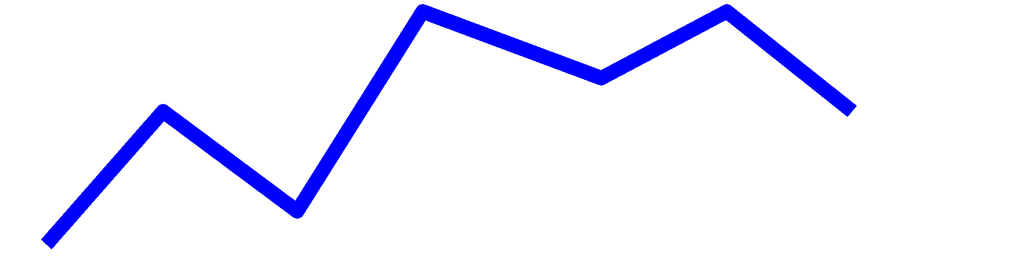

Deep Temp (degC)

18.00

19.00

20.00

22.00

24.00

24.00

23.00

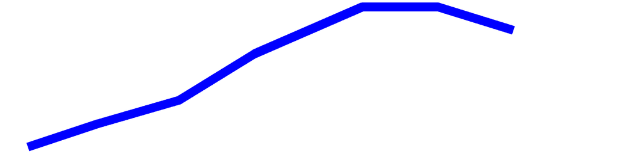

FP BG Chl.a (ug/L)

1.72

1.50

0.99

3.49

10.54

25.46

45.74

21.83

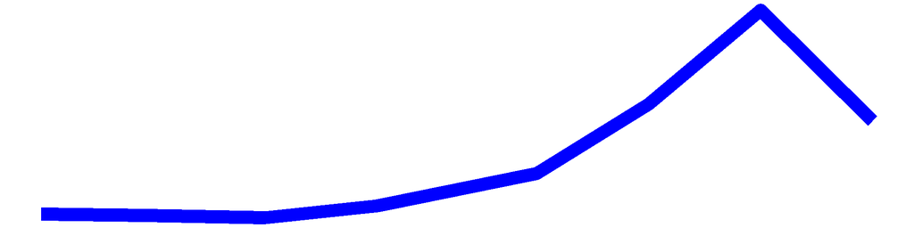

## Cossayuna Lake – Sampling Season Results

### HABs Status

#### Open Water Algae

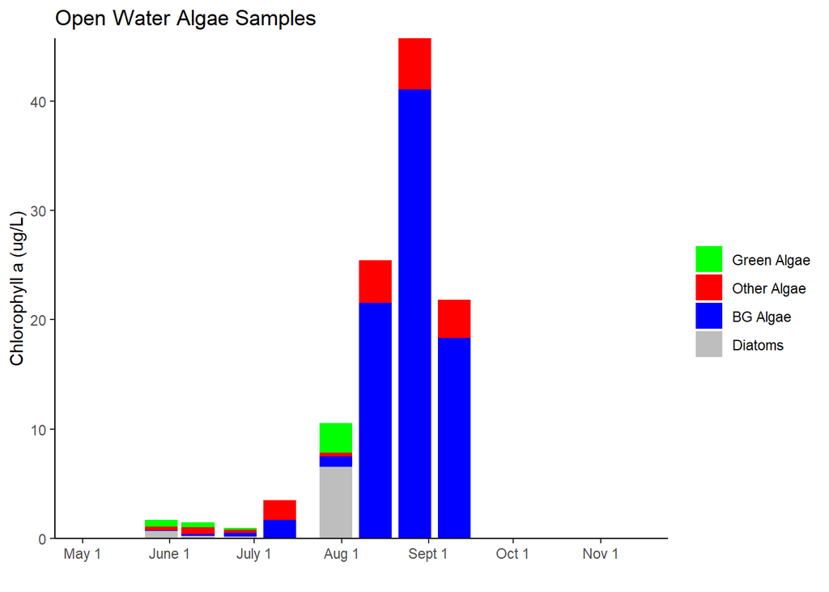

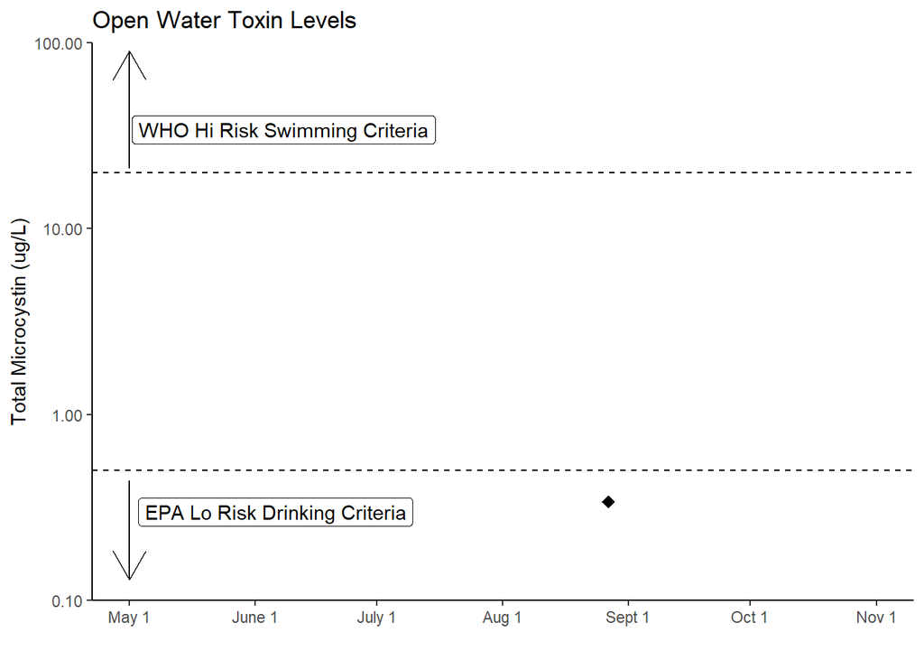

#### Shoreline Algae

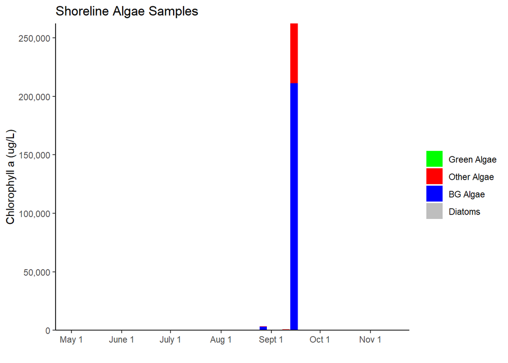

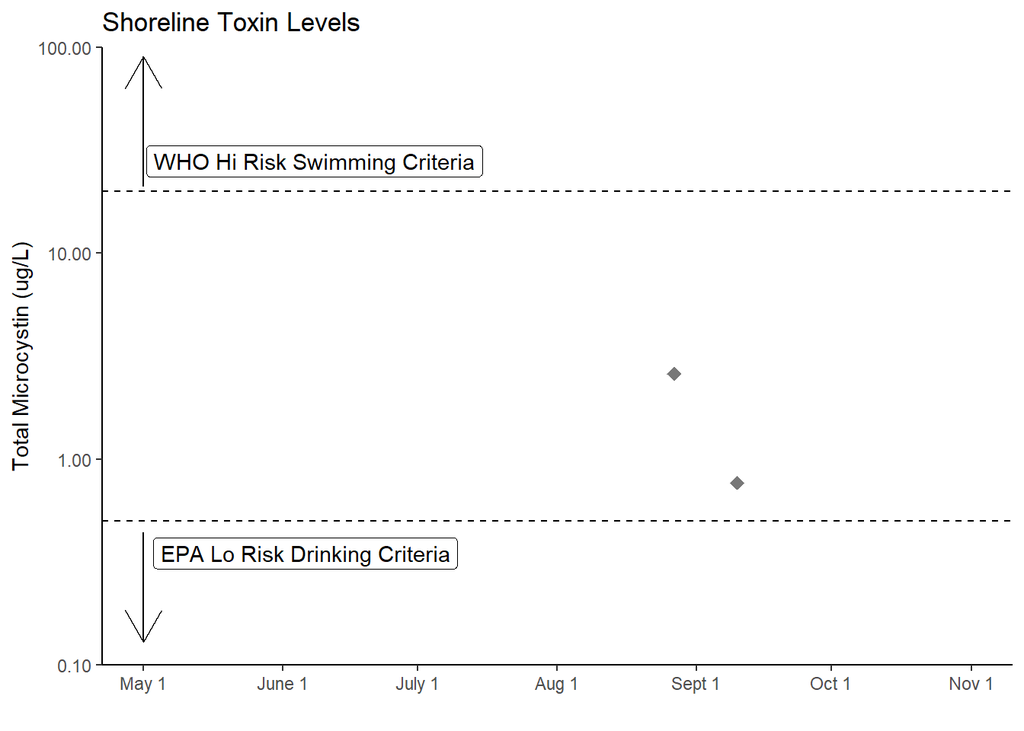

## Cossayuna Lake Long-Term Trend Analysis

#### Clarity

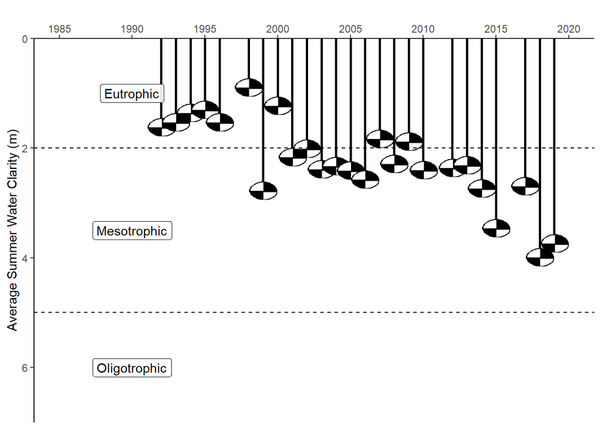

#### Chlorophyll *a*

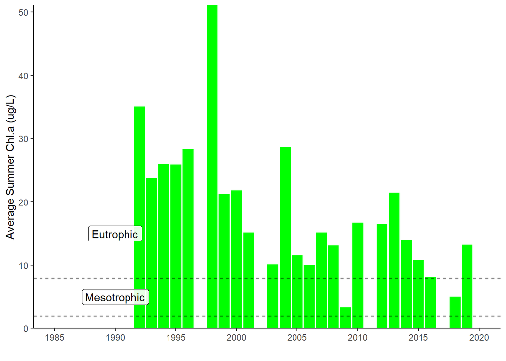

#### Surface and Deep Phosphorus

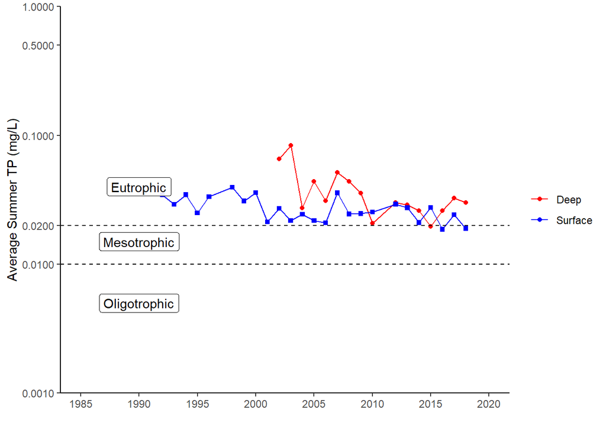

#### Nitrogen

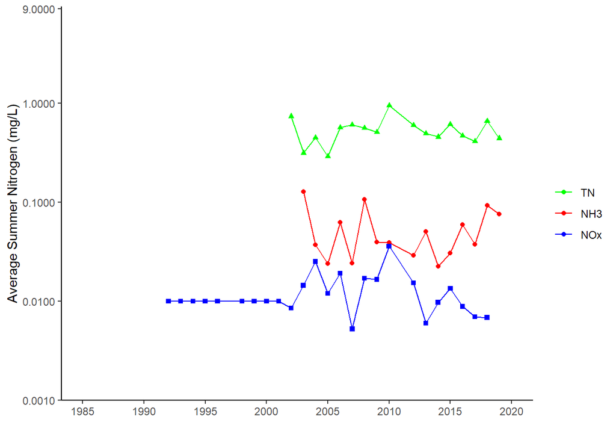

#### TN : TP

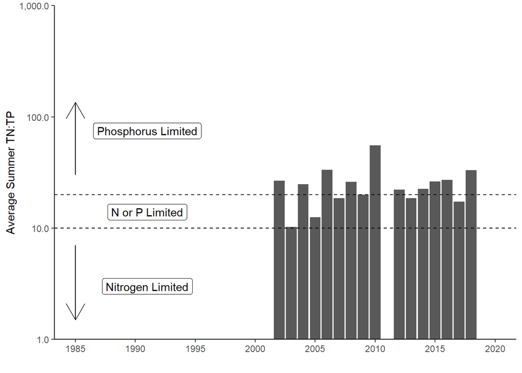

#### pH

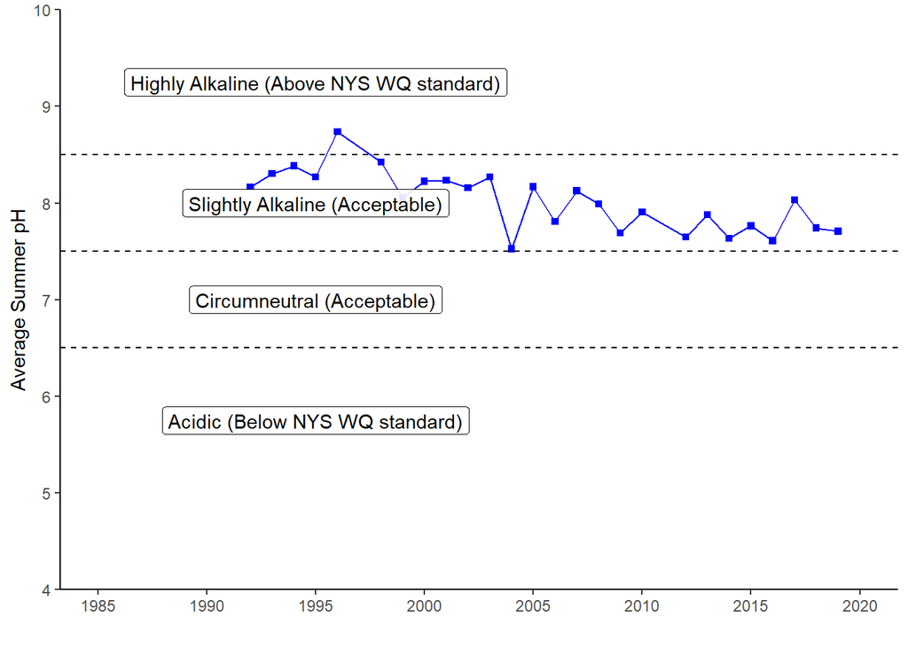

#### Specific Conductance

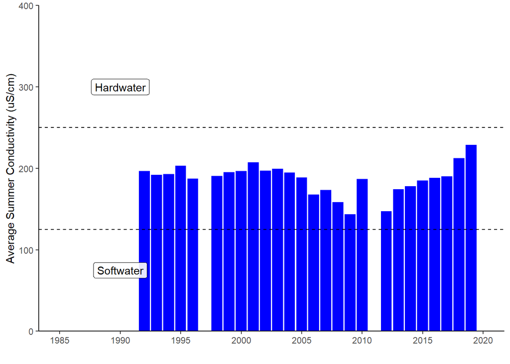

#### Calcium

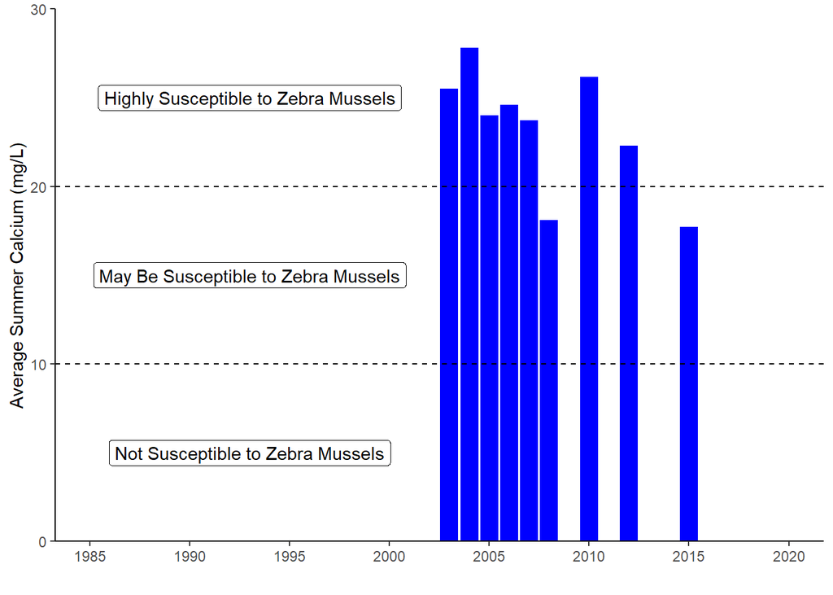

#### Chloride

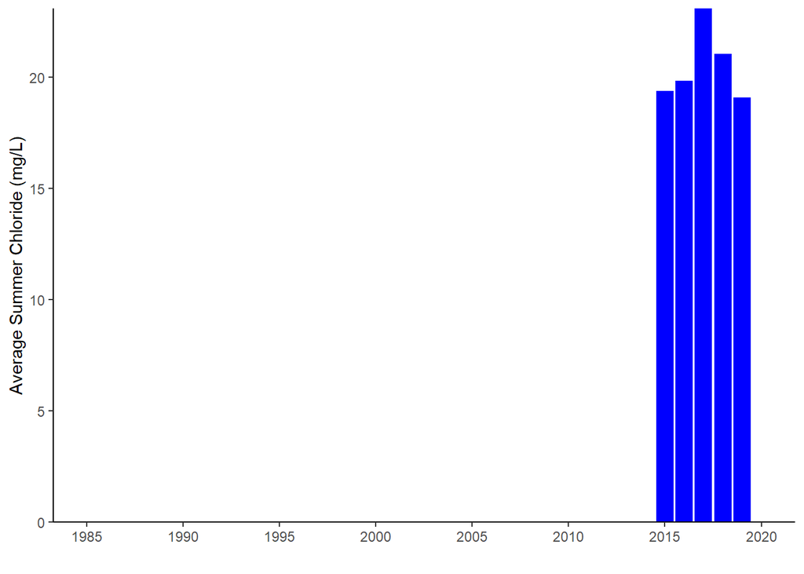

#### Color

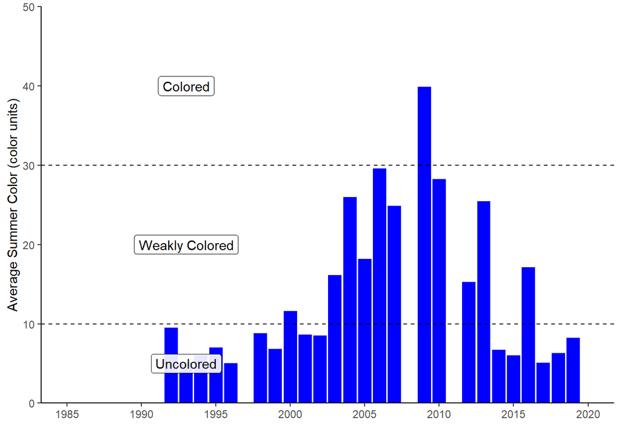